# The affect of land use and disturbance to the global carbon cycle

Jack Wassik

14-Mar-2019

# Introduction

Continuing increases in global CO2 (carbon dioxide) emissions have created greater changes to the global climate, impacting not only the environment, but the way we live. However, carbon emissions can originate in other forms such as dissolved organic carbon (DOC) which can degass into the atmosphere. All of these increasing carbon contributions have placed great significance on the global environment, and what can disturb it, calling for greater understanding of the biogeosciences (Eglinton, 2015).

By understanding these important biogeochemical systems, such as the global carbon cycle, and how they respond to natural and anthropogenic disturbances, we can better understand and mitigate further disruptions (Eglinton, 2015). Despite the carbon cycles importance, until recently it has been simplified to three major sources: continents (terrestrial source), oceans, and the atmopshere, with the first two being the major sources of biological processes that degass into the atmosphere (Cole et al., 2007). This simplification present large gaps within our knowledge and understanding of what factors can control and impact the global carbon cycle. This issue has furthered countless research in recent years, predominantly in the past decade, in order to learn more about the intricacies within the global carbon cycle. Though, this has still created a large gap in our knowledge of inland aquatic carbon systems, specifically rivers, which remain poorly constrained (Cole et al., 2007).

Rivers have been understood to play an essential role within the greater global carbon cycle, linking and reacting DOC from both terrestrial sources to oceanic sources through transport and the atmosphere through degassing (Cole et al., 2007, Wang et al., 2018). Though, the significance of rivers has increased, our understanding has not. Cole et al., 2007 estimated that rivers outgasses 1.4 petragrams (10^15 grams) of CO2 per year. However, more recent estimates have placed that value at 1.8 petrgrams of CO2 per year, placing the amount on the same magnitude as anthropogenic burning of fossil fuels (7.9 petragrams of CO2 per year) (Ward et al., 2017). Given this significant contribution of CO2, there is a greater need to characterize rivers within the global carbon cycle (Raymond et al., 2013).

Even with growing attention, factors that control both the amount and reactivity of organic carbon in rivers remain unknown (Raymond et al., 2004). Factors such as large geological disturbances, land use, and anthropogenic forcing can have unknown affects on the amount and reaction of organic carbon within rivers. Furthermore, understanding the age of DOC adds another level of complexity to river carbon cycling. Buried or petrogenic carbon can possibly be released due to natural (erosion) or anthropogenic (mining) factors, that may have unknown affects to both concentrations and reactions of DOC (Hemingway et al., 2018).

Using data collected over the summer of 2018 and analysed within this course, this report aims to understand the geological and land use factors that affect river carbon cycling and how this can affect the greater carbon cycle itself.

# Programs and all data files

## Loading in the necessary programs

## Loading in all data files

# Sampling Sites

## Map of all sampling sites

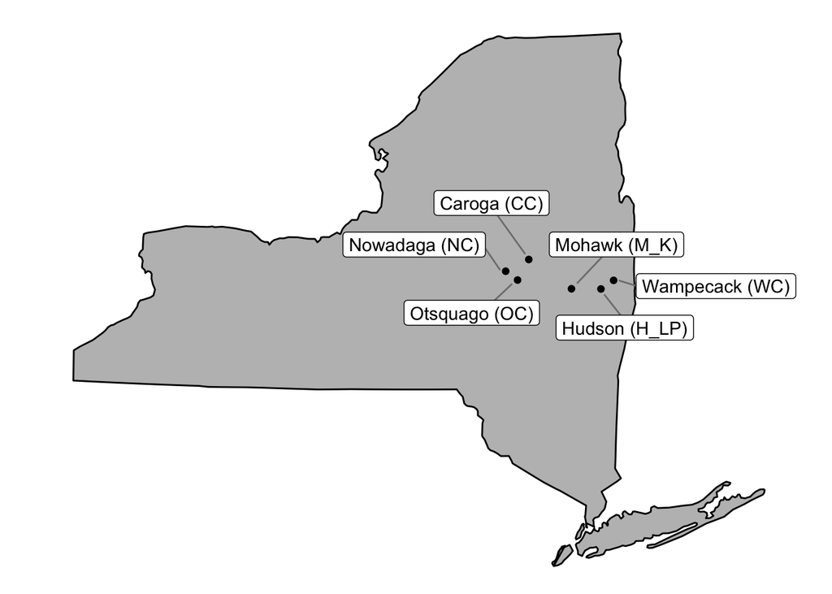

### Figure 1

Map of New York State with all six sampling sites labeled with creek/river name and site abbreviation. Site abbreviation used within the remainder of this report. All sites were sampled during baseflow conditions between July and August of 2018. [6] Site data latitude-longitude source.

## Creating bar graph representing the proportion of land use

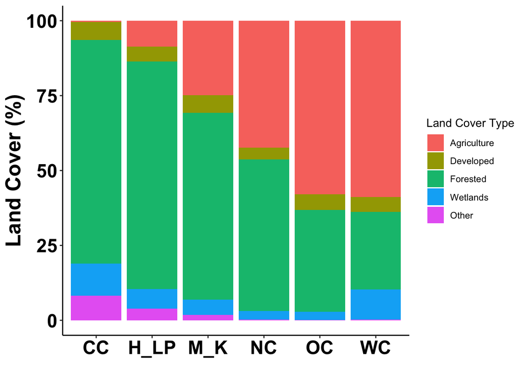

### Figure 2

Proportions of five major types of land use (Agriculture, Developed, Forested, Wetlands, and other) within each watershed denoted by site abbreviation. [3] Land use data source. From this graph, which land use dominates each site can be denoted, for instance both Caroga and Hudson watersheds are predominantly forested, while Otsqaugo and Wampecack are dominated by agriculture.

# DOC Concentration and Proportion analysis

## Creating start/end summary tables for UCSB for general experimental information

## Binding the start and end summary tables for UCSB DOC data

| Site | Exp_Con | S_E | Exp_num | DOC_avg | Exp_code |
| --- | --- | --- | --- | --- | --- |
| CC | EXP | Start | 0 | 4.308192 | Start-0 |
| H_LP | EXP | Start | 0 | 3.900119 | Start-0 |
| M_K | EXP | Start | 0 | 2.703035 | Start-0 |
| NC | EXP | Start | 0 | 1.559903 | Start-0 |
| OC | EXP | Start | 0 | 1.403536 | Start-0 |
| WC | EXP | Start | 0 | 3.126228 | Start-0 |
| CC | EXP | End | 1 | 4.068551 | End-1 |
| CC | EXP | End | 2 | 4.074350 | End-2 |
| CC | EXP | End | 3 | 4.027789 | End-3 |
| H_LP | EXP | End | 1 | 3.487087 | End-1 |

[output cut: 14 more lines]

### Table 1

Summary table for Averaged initial DOC concentrations and triplicate final DOC concentrations, both measured in milligrams per liter. This table was generated from the initial and final DOC concentration tables in order to visualize the data. This table presents Site name, Experiment or Control denominantion, Start or End denomination, Experiment number, DOC average or concentration (mg/L), and Experiment code. [1] DOC data source.

## Creating a Bar graph for UCSB Data

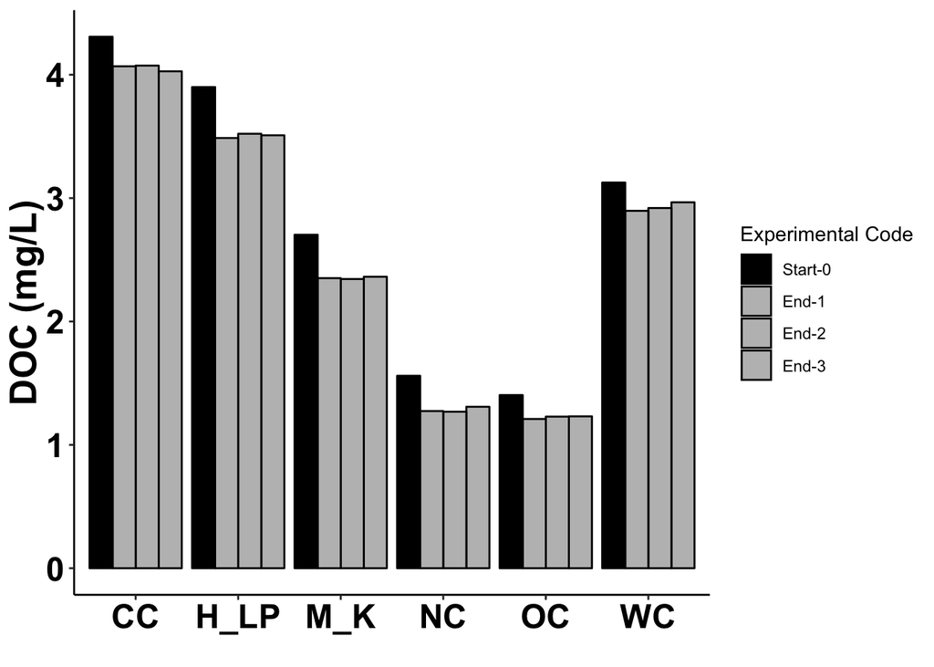

### Figure 3

Average initial DOC concentrations compared to triplicate end DOC contrations for each site. All concentrations measured in milligrams per liter. Start DOC concentrations (mg/L) represented by black bars, while end triplicate experiment concentrations (mg/L) represented by gray bars. This initial graph shows that per each site, different trends of concentrations exist.

## Creating summary table for UCSB Labile DOC concentrations

| Site | Start-0 | End-1 | End-2 | End-3 | Exp_code | Labile_DOC | percent_labile | alpha |
| --- | --- | --- | --- | --- | --- | --- | --- | --- |
| CC | 4.308192 | 4.068551 | 4.074350 | 4.027789 | Labile1_DOC_mgL | 0.2396401 | 5.562428 | 0.05562428 |
| H_LP | 3.900119 | 3.487087 | 3.521641 | 3.509087 | Labile1_DOC_mgL | 0.4130317 | 10.590234 | 0.10590234 |
| M_K | 2.703035 | 2.351654 | 2.344196 | 2.362840 | Labile1_DOC_mgL | 0.3513815 | 12.999514 | 0.12999514 |
| NC | 1.559903 | 1.273876 | 1.268579 | 1.308822 | Labile1_DOC_mgL | 0.2860276 | 18.336237 | 0.18336237 |
| OC | 1.403536 | 1.209825 | 1.228778 | 1.231037 | Labile1_DOC_mgL | 0.1937112 | 13.801657 | 0.13801657 |
| WC | 3.126228 | 2.897184 | 2.919743 | 2.966354 | Labile1_DOC_mgL | 0.2290443 | 7.326538 | 0.07326538 |
| CC | 4.308192 | 4.068551 | 4.074350 | 4.027789 | Labile2_DOC_mgL | 0.2338416 | 5.427837 | 0.05427837 |
| H_LP | 3.900119 | 3.487087 | 3.521641 | 3.509087 | Labile2_DOC_mgL | 0.3784777 | 9.704262 | 0.09704262 |
| M_K | 2.703035 | 2.351654 | 2.344196 | 2.362840 | Labile2_DOC_mgL | 0.3588391 | 13.275414 | 0.13275414 |
| NC | 1.559903 | 1.273876 | 1.268579 | 1.308822 | Labile2_DOC_mgL | 0.2913241 | 18.675776 | 0.18675776 |

[output cut: 8 more lines]

### Table 2

Labile DOC concentrations for each triplicate experiments measured in milligrams per liter. This table also presents a Labile DOC percentage and alpha values.

## Comparing the amounts of labile versus initial DOC concentrations

```
##  [1] "Site"           "Exp_Con"        "S_E"            "Exp_num"
##  [5] "DOC_avg"        "Start-0"        "End-1"          "End-2"
##  [9] "End-3"          "Exp_code"       "Labile_DOC"     "percent_labile"
## [13] "alpha"          "Geology"
```

## Creating scatter plot graph for labile versus initial DOC UCSB

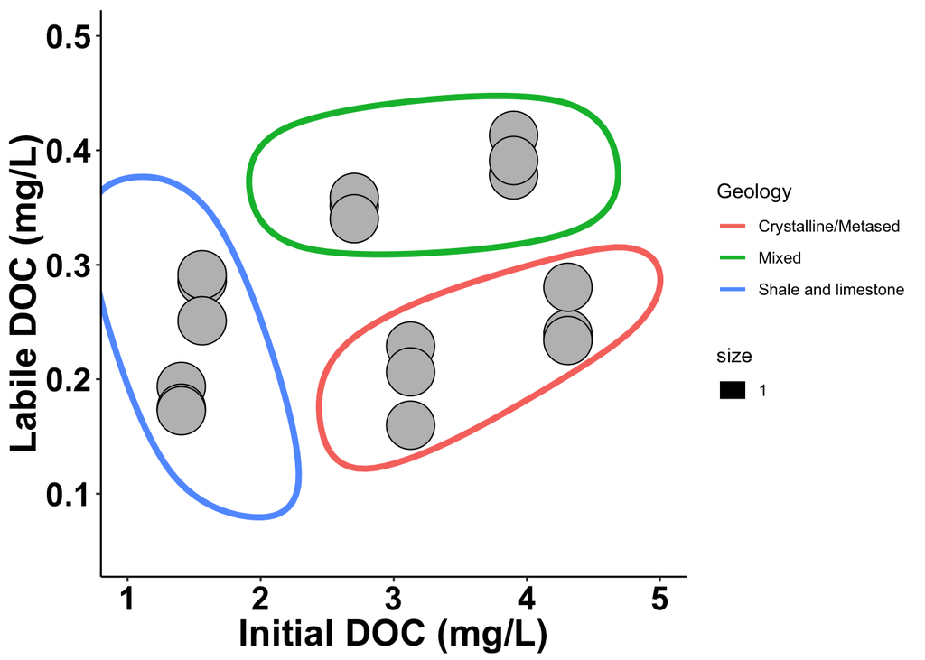

### Figure 4

Scatter plot graph comparing the Initial DOC concentration (mg/L) to the Labile DOC concentration (mg/L). The encircled region represents the populations based on the watershed geology [5]. This figure shows that geology does affect both the initial and labile concentrations of DOC within the rivers.

## Creating Summary Table for UCSB Labile DOC proportions

| Site | Start-0 | End-1 | End-2 | End-3 | Exp_code | Percent_delta_DOC |
| --- | --- | --- | --- | --- | --- | --- |
| CC | 4.308192 | 4.068551 | 4.074350 | 4.027789 | percent_exp_1 | 5.562428 |
| H_LP | 3.900119 | 3.487087 | 3.521641 | 3.509087 | percent_exp_1 | 10.590234 |
| M_K | 2.703035 | 2.351654 | 2.344196 | 2.362840 | percent_exp_1 | 12.999514 |
| NC | 1.559903 | 1.273876 | 1.268579 | 1.308822 | percent_exp_1 | 18.336237 |
| OC | 1.403536 | 1.209825 | 1.228778 | 1.231037 | percent_exp_1 | 13.801657 |
| WC | 3.126228 | 2.897184 | 2.919743 | 2.966354 | percent_exp_1 | 7.326538 |
| CC | 4.308192 | 4.068551 | 4.074350 | 4.027789 | percent_exp_2 | 5.427837 |
| H_LP | 3.900119 | 3.487087 | 3.521641 | 3.509087 | percent_exp_2 | 9.704262 |
| M_K | 2.703035 | 2.351654 | 2.344196 | 2.362840 | percent_exp_2 | 13.275414 |
| NC | 1.559903 | 1.273876 | 1.268579 | 1.308822 | percent_exp_2 | 18.675776 |

[output cut: 8 more lines]

### Table 3

## Labile DOC proportion bar graph

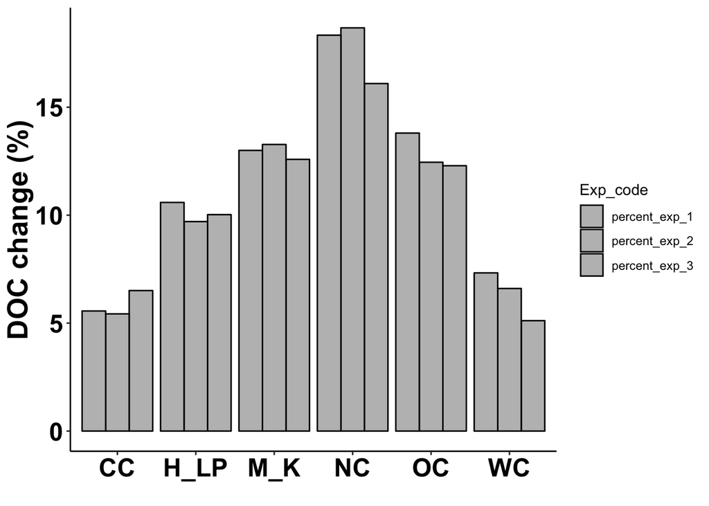

## Labile DOC versus site Geology

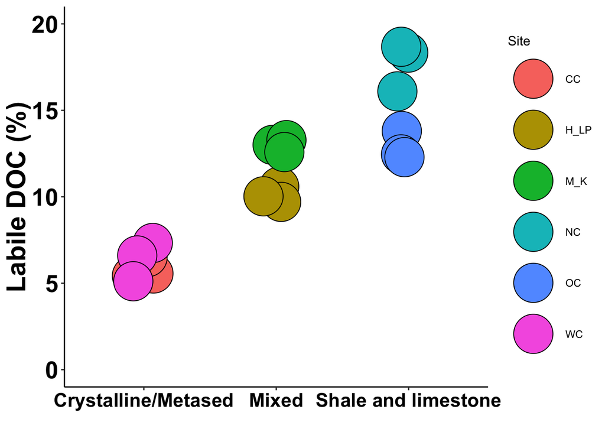

### Figure 6

Labile DOC propotions measured in percent, compared against watershed site geology [4]. This scatter plot graph shows how geology does affect the proportion or percentage of Labile DOC with shale-limestone having the highest proportions and crystalline-metasedimentary having the lowest proportions.

# DOC Age calculations

## Graphing start age versus labile age

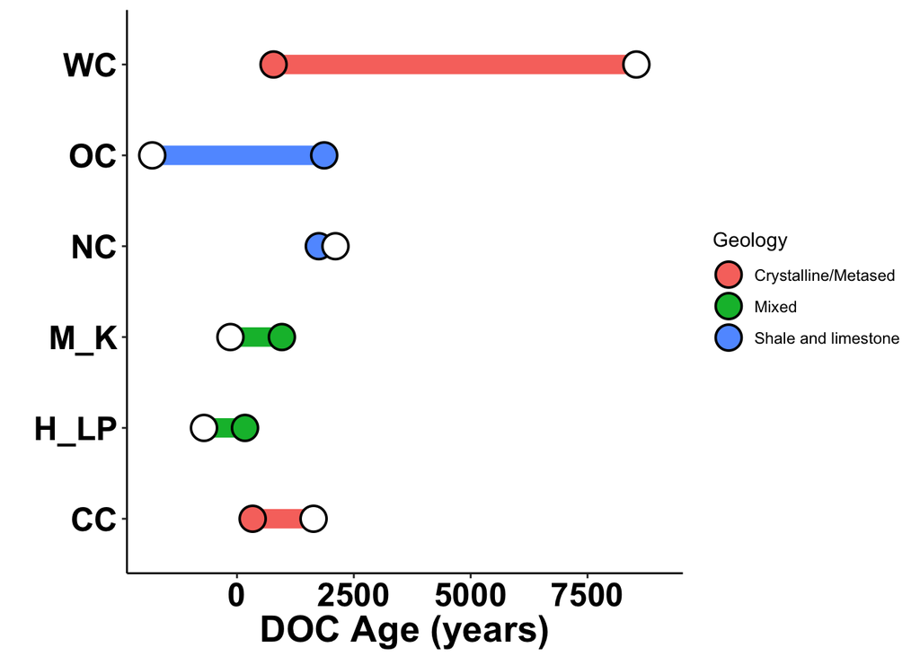

### Figure 7

Dumbbell plot comparing the initial DOC ages to the labile DOC ages with the full circle representing the initial age and the hollow circle representing the labile age. Trends exist based on geology with crystalline-metased geology having a younger Bulk DOC than labile DOC, while mixed geology has an older Bulk DOC age than labile DOC age.

## d13C versus agriculture percentage

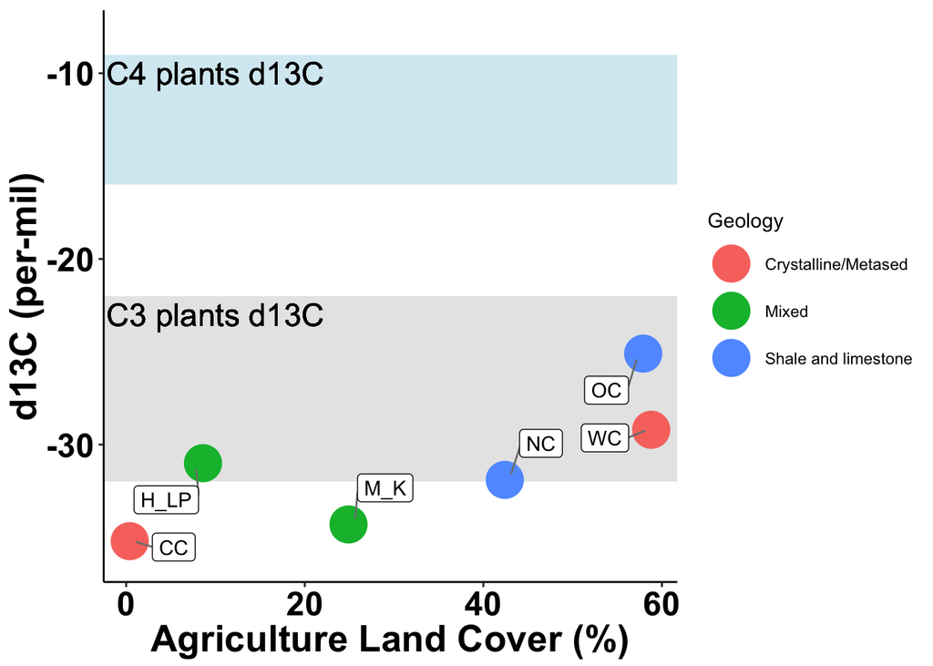

### Figure 8

Comparison of d13C values (per-mil) compared to each sites proportion of agriculture. Highlighted regions are labeled, but denote the d13C values recorded by Kendall et al., 2001 for C3/C4 plants and soils.

## d15N versus agriculture percentage

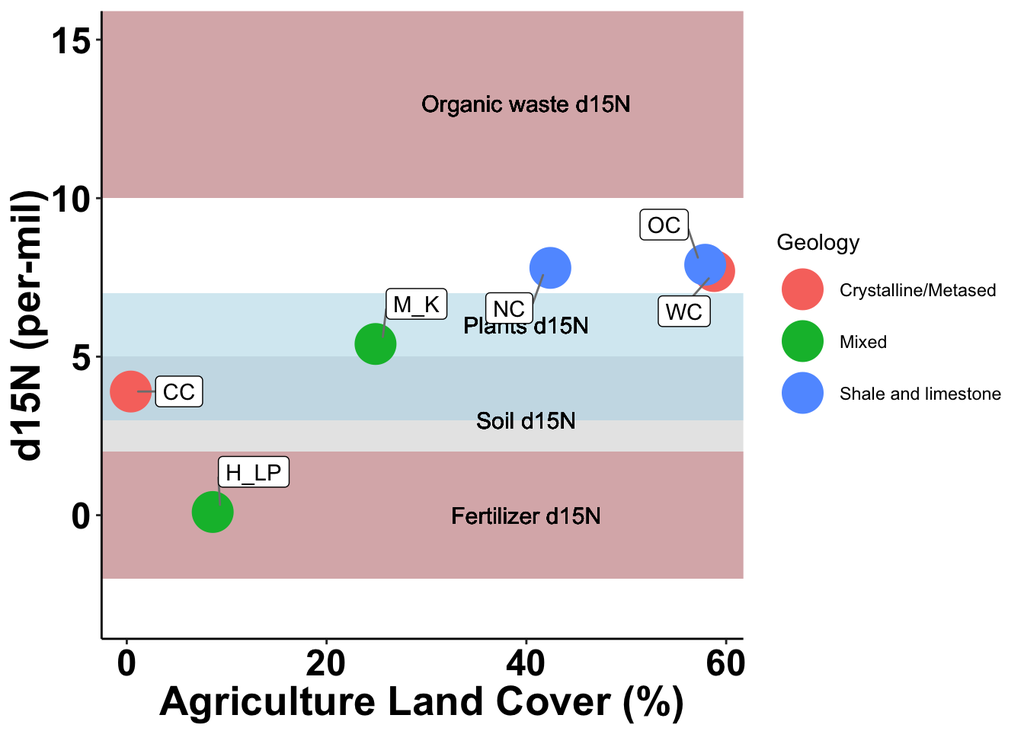

### Figure 9

Comparison of d15N (per-mil) values to the proportion of agriculutre for each site. Highlighted regions are labeled, but denote the d15N values recorded by Kendall et al., 2001 for plants, soils, fertilizer, and organic waste.

## d13C versus forested land use coverage

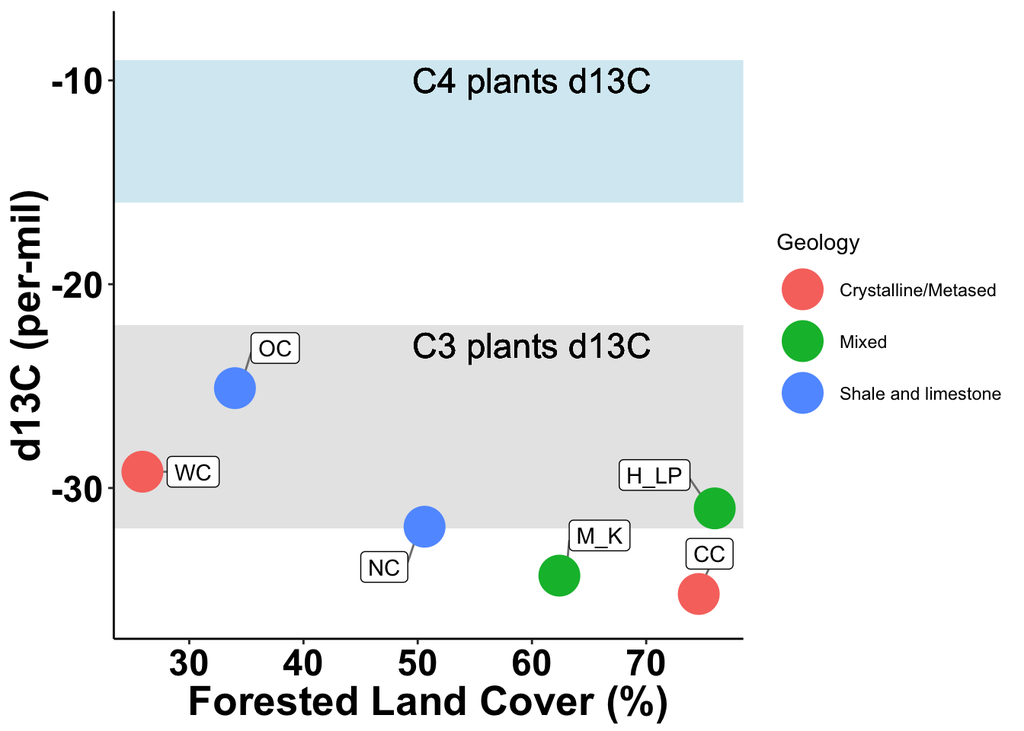

### Figure 10

Comparison of d13C values (per-mil) compared to each sites proportion of forested land. Highlighted regions are labeled, but denote the d13C values recorded by Kendall et al., 2001 for C3/C4 plants and soils.

## d15N versus forested land use coverage

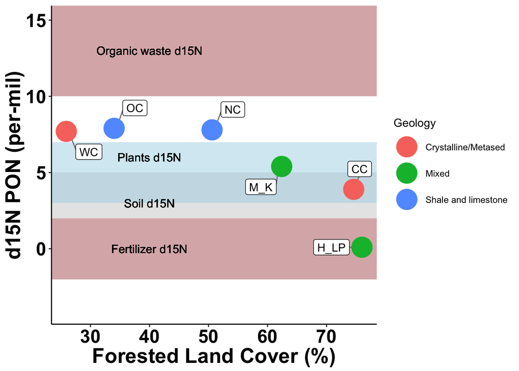

### Figure 11

Comparison of d15N (per-mil) values to the proportion of forested land for each site. Highlighted regions are labeled, but denote the d15N values recorded by Kendall et al., 2001 for plants, soils, fertilizer, and organic waste.

## d13C vs Developed Land Cover

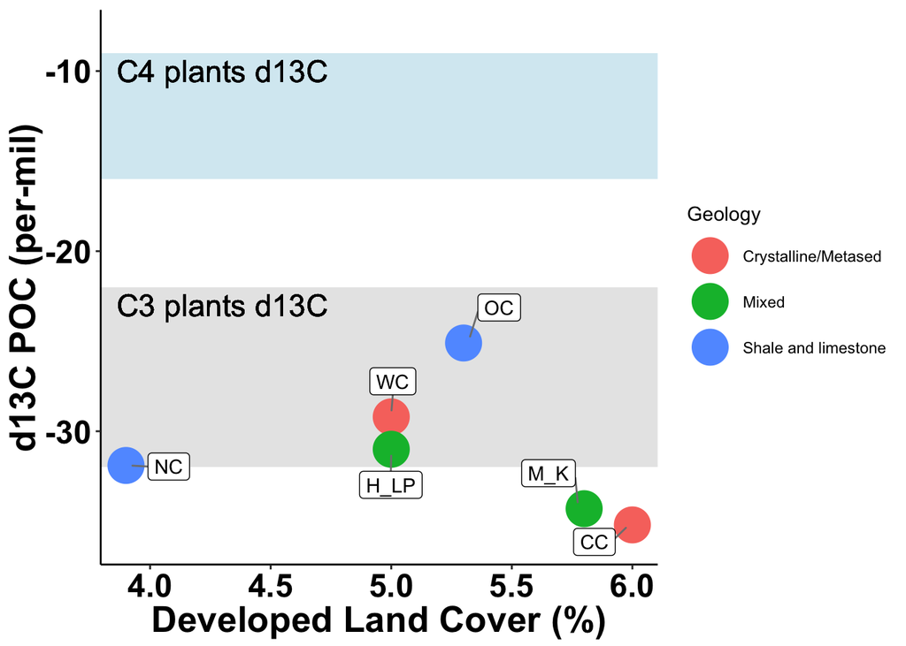

### Figure 12

Comparison of d13C values (per-mil) compared to each sites proportion of developed land. Highlighted regions are labeled, but denote the d13C values recorded by Kendall et al., 2001 for C3/C4 plants and soils.

## d15N versus Developed Land Cover

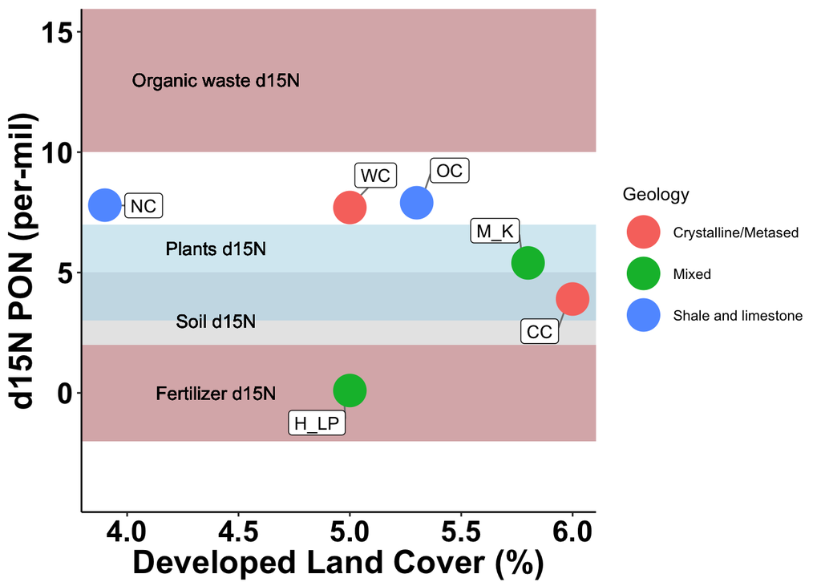

### Figure 13

Comparison of d15N (per-mil) values to the proportion of developed land for each site. Highlighted regions are labeled, but denote the d15N values recorded by Kendall et al., 2001 for plants, soils, fertilizer, and organic waste.

# Discussion

The six sampling sites (Figure 1) present a variety of different land uses (Figure 2) as well as geologies, allowing for better interpretation of how these factors can affect carbon concentrations, proportions, and ages.

DOC concentration analysis (Table 1) shows that ultimately land use impacts the concentrations of DOC. Both Caroga Creek and the Hudson River’s watersheds, both having the greatest proportion of forested land (Figure 2) also have the highest DOC concentrations (Figure 3), whereas Otsquago and Nowadaga Creeks watersheds have higher proportions of agriculture (Figure 2) and the lowest concentrations of DOC (Figure 3). This may arise from the fact that whereas in agriculture, crops and thus organic matter is collected for later distribution, whereas organic matter in forests is not controlled/collected. This lack of control would allow greater amounts of organic matter to eventually reach rivers and then be dissolved for into DOC. By calculating the concentration of labile or reacted DOC (Table 2), we can understand the quantity of DOC that was reacted during the incubation experiments. When comparing the concentrations of Labile DOC to initial DOC we observe that geology influences both of these concentrations (Figure 4). Thus, like land use proportions, site geology can affect the quantity of both labile and initial DOC within these rivers.

This claim can further be substantiated by the C14 Age analysis of Labile DOC and then comparing it to the initial DOC (Figure 7). Again geology controls the trends with C14 age. Both Crsytalline-Metasedmintary sites have younger Bulk DOC ages compared to their labile DOC ages, indicating that once mobilized, petrogenic DOC is consumed compared to younger DOC (Figure 7). Contralily, in both the mixed and the shale-limestone watersheds, labile DOC is younger than bulk DOC, indicating that even though petrogenic DOC is available, younger DOC is prefered (Figure 7). However, one site does seem to stray from this trend, Nowadaga has labile DOC older than its younger DOC, however there is not a large difference, which is interpreted as having the same age (Figure 7).

Finally, no trends appear to exist between d13C and d15N and the developed land cover (Figure 12, Figure 13). Nor do any factors appear to control the d13C and d15N values that could be a result of developed land cover. It should be noted that compared to agriculutre and forested proportions, developed cover is much smaller (Figure 2).

# Conclusion

In conclusion both land use and site geology appear to control the concentrations, proportions, and age of DOC cycled in each river. This prompts us to better understand how we as humans are impacting these factors, and thus impacting the carbon cycle. Further study would have to better understand and quantify the anthropogenic control on land use and geology on carbon cycling. This would allow us to better control how we as a species are impacting the carbon cycle other than the direct emission of CO2.

# References

### Cole, J. J., Prairie, Y. T., Caraco, N. F., Mcdowell, W. H., Tranvik, L. J., Striegl, R. G., … Melack, J. (2007). Plumbing the Global Carbon Cycle : Integrating Inland Waters into the Terrestrial Carbon Budget, 171–184. https://doi.org/10.1007/s10021-006-9013-8

### Eglinton, T. I. (2015). Grand challenges in biogeoscience, 3(July), 1–5. https://doi.org/10.3389/feart.2015.00039

### Hemingway, J. D., Hilton, R. G., Hovius, N., Eglinton, T. I., Haghipour, N., Wacker, L., … & Galy, V. V. (2018). Microbial oxidation of lithospheric organic carbon in rapidly eroding tropical mountain soils. Science, 360(6385), 209-212.

### Raymond, P. A., Bauer, J. E., Caraco, N. F., Cole, J. J., Longworth, B., & Petsch, S. T. (2004). Controls on the variability of organic matter and dissolved inorganic carbon ages in northeast US rivers. Marine Chemistry, 92(1-4), 353-366.

### Raymond, P. A., Hartmann, J., Lauerwald, R., Sobek, S., McDonald, C., Hoover, M., … & Kortelainen, P. (2013). Global carbon dioxide emissions from inland waters. Nature, 503(7476), 355.

### Wang, X., Yoo, K., Mudd, S. M., Weinman, B., Gutknecht, J., & Gabet, E. J. (2018). Storage and export of soil carbon and mineral surface area along an erosional gradient in the Sierra Nevada, California. Geoderma, 321, 151-163.